# Earthquakes in 1910-2017, Turkey

Jinqian Pan

10/27/2018

# Introduction

Over the years the earthquakes have been recorded by different organisations in Turkey. Bogazici University, as the most successful university in Turkey, has a earthquake research center and they collected up all the data during the years. They have the most technological devices to uncover the specifications about the earthquakes. The data was collected from the database with particular filters.

The data covers up all the recorded earthquakes in the latitudes between 25 - 50; longitudes 15 - 60. As the metering stations are placed in Turkey most of the recorded earthquakes are in latitudes between 35 - 45; longitudes 25 - 45. The database search time filter was set to dates 27/09/1910 to 27/09/2017. As there are too many earthquakes which have intensities smaller than 4.0, the filter of intensity was set to 3.5 to 9.0 (there was no earthquakes recorded larger than 9.0 intensity). Not being an earthquake specilist or geologist, I have no idea about the different kind of intensity measurements in the dataset (the columns between xM and Ms).

https://www.kaggle.com/caganseval/earthquake/home

## Reading the Data

```r
Total_data <- read.csv("/Users/jinqian_pan/Desktop/MATH3700/bigdata2018/projects/earthquake.csv")
```

## library

```r
library(dplyr)
library(fmsb)
library(ggmap)
```

```r
library(ggplot2)
library(lubridate)
```

# Variable definitions

This data is about earthquakes in 1910-2017, Turkey.

- “id”: the casenumber of earthquakes
- “data” & “time”: the time of earthquakes
- “lat” & “long”: the latitude and longitude of earthquakes
- “counrey”, “city”, “area”: the place of earthquakes
- “direction”: the direction of earthquake
- “dist” & “depth”: the distance and depth of direction in km
- “xm”, “md”, “richter”, “mw”, “ms”, “mb”: the different kind of intensity measurements of earthquakes

```r
head(Total_data)
```

```
##         id       date        time   lat  long country    city
## 1 2.00e+13 2003.05.20 12:17:44 AM 39.04 40.38  turkey  bingol
## 2 2.01e+13 2007.08.01 12:03:08 AM 40.79 30.09  turkey kocaeli
## 3 1.98e+13 1978.05.07 12:41:37 AM 38.58 27.61  turkey  manisa
## 4 2.00e+13 1997.03.22 12:31:45 AM 39.47 36.44  turkey   sivas
## 5 2.00e+13 2000.04.02 12:57:38 AM 40.80 30.24  turkey sakarya
## 6 2.01e+13 2005.01.21 12:04:03 AM 37.11 27.75  turkey   mugla
##                  area  direction dist depth  xm  md richter mw ms  mb
## 1          baliklicay       west  0.1  10.0 4.1 4.1       0 NA  0 0.0
## 2     bayraktar_izmit       west  0.1   5.2 4.0 3.8       4 NA  0 0.0
## 3          hamzabeyli south_west  0.1   0.0 3.7 0.0       0 NA  0 3.7
## 4 kahvepinar_sarkisla south_west  0.1  10.0 3.5 3.5       0 NA  0 0.0
## 5     meseli_serdivan south_west  0.1   7.0 4.3 4.3       0 NA  0 0.0
## 6    demirciler_milas south_west  0.1  32.8 3.5 3.5       0 NA  0 0.0
```

```r
dim(Total_data)
```

```
## [1] 24007    17
```

```r
str(Total_data)
```

```
## 'data.frame':    24007 obs. of  17 variables:
##  $ id       : num  2.00e+13 2.01e+13 1.98e+13 2.00e+13 2.00e+13 ...
##  $ date     : Factor w/ 12218 levels "1910.12.04","1911.03.11",..: 8571 9586 3302 7288 7915 8951 10875 5284 7884 10675 ...
##  $ time     : Factor w/ 3594 levels "1:00:00 AM","12:00:00 AM",..: 1064 190 2495 1903 3455 245 444 2992 707 2874 ...
##  $ lat      : num  39 40.8 38.6 39.5 40.8 ...
##  $ long     : num  40.4 30.1 27.6 36.4 30.2 ...
##  $ country  : Factor w/ 26 levels "#NAME?","aegeansea",..: 20 20 20 20 20 20 20 20 20 20 ...
##  $ city     : Factor w/ 94 levels "","adana","adiyaman",..: 18 59 65 83 77 69 90 13 56 90 ...
##  $ area     : Factor w/ 5322 levels "","abali_adapazari",..: 620 706 2447 2732 3670 1540 2602 1631 3283 1523 ...
##  $ direction: Factor w/ 9 levels "","east","north",..: 9 9 8 8 8 8 8 7 7 7 ...
##  $ dist     : num  0.1 0.1 0.1 0.1 0.1 0.1 0.1 0.1 0.1 0.1 ...
##  $ depth    : num  10 5.2 0 10 7 32.8 9.4 26 1 3.1 ...
##  $ xm       : num  4.1 4 3.7 3.5 4.3 3.5 4.5 3.8 3.8 4.3 ...
##  $ md       : num  4.1 3.8 0 3.5 4.3 3.5 0 3.8 3.8 0 ...
##  $ richter  : num  0 4 0 0 0 0 4.5 0 0 4.2 ...
##  $ mw       : num  NA NA NA NA NA NA NA NA NA NA ...
##  $ ms       : num  0 0 0 0 0 0 0 0 0 0 ...
##  $ mb       : num  0 0 3.7 0 0 0 0 0 0 4.3 ...
```

Because “id”s are unique number and the provider do not know what “xm”, “md”, “mw”, “ms”, “mb” means, I just choose another columns.

## Choose data

```r
using_data <- Total_data %>% select(date, time, lat, long, country, city, area, direction, dist, depth, richter)
head(using_data)
```

```
##         date        time   lat  long country    city                area
## 1 2003.05.20 12:17:44 AM 39.04 40.38  turkey  bingol          baliklicay
## 2 2007.08.01 12:03:08 AM 40.79 30.09  turkey kocaeli     bayraktar_izmit
## 3 1978.05.07 12:41:37 AM 38.58 27.61  turkey  manisa          hamzabeyli
## 4 1997.03.22 12:31:45 AM 39.47 36.44  turkey   sivas kahvepinar_sarkisla
## 5 2000.04.02 12:57:38 AM 40.80 30.24  turkey sakarya     meseli_serdivan
## 6 2005.01.21 12:04:03 AM 37.11 27.75  turkey   mugla    demirciler_milas
##    direction dist depth richter
## 1       west  0.1  10.0       0
## 2       west  0.1   5.2       4
## 3 south_west  0.1   0.0       0
## 4 south_west  0.1  10.0       0
## 5 south_west  0.1   7.0       0
## 6 south_west  0.1  32.8       0
```

```r
summary(using_data)
```

```
##          date                time            lat             long
##  2011.10.23:   78   12:00:01 AM:   27   Min.   :29.74   Min.   :18.34
##  2017.07.21:   60   12:30:00 AM:   21   1st Qu.:36.19   1st Qu.:26.20
##  2011.10.24:   56   12:00:00 AM:   20   Median :38.20   Median :28.35
##  2011.10.25:   48   12:49:04 AM:   19   Mean   :37.93   Mean   :30.77
##  1981.03.05:   41   12:45:00 AM:   18   3rd Qu.:39.36   3rd Qu.:33.85
##  1981.02.25:   40   12:02:00 AM:   17   Max.   :46.35   Max.   :48.00
##  (Other)   :23684   (Other)    :23885
##           country             city                   area
##  turkey       :11850            :12253                 :11030
##  mediterranean: 4843   mugla    : 1095   girit_adasi   :  452
##  greece       : 3560   van      :  900   oniki_adalar  :  343
##  aegeansea    : 1748   izmir    :  700   gokova_korfezi:  292
##  iran         :  346   kutahya  :  687   midilli_adasi :  137
##  georgia      :  322   canakkale:  525   saros_korfezi :  134
##  (Other)      : 1338   (Other)  : 7847   (Other)       :11619
##       direction          dist            depth           richter
##            :13945   Min.   : 0.100   Min.   :  0.00   Min.   :0.000
##  north_west: 2019   1st Qu.: 1.400   1st Qu.:  5.00   1st Qu.:0.000
##  south_west: 2011   Median : 2.300   Median : 10.00   Median :3.500
##  south_east: 1917   Mean   : 3.175   Mean   : 18.49   Mean   :2.197
##  north_east: 1901   3rd Qu.: 3.600   3rd Qu.: 22.40   3rd Qu.:4.000
##  south     :  605   Max.   :95.400   Max.   :225.00   Max.   :7.200
##  (Other)   : 1609   NA's   :13945
```

```r
str(using_data)
```

```
## 'data.frame':    24007 obs. of  11 variables:
##  $ date     : Factor w/ 12218 levels "1910.12.04","1911.03.11",..: 8571 9586 3302 7288 7915 8951 10875 5284 7884 10675 ...
##  $ time     : Factor w/ 3594 levels "1:00:00 AM","12:00:00 AM",..: 1064 190 2495 1903 3455 245 444 2992 707 2874 ...
##  $ lat      : num  39 40.8 38.6 39.5 40.8 ...
##  $ long     : num  40.4 30.1 27.6 36.4 30.2 ...
##  $ country  : Factor w/ 26 levels "#NAME?","aegeansea",..: 20 20 20 20 20 20 20 20 20 20 ...
##  $ city     : Factor w/ 94 levels "","adana","adiyaman",..: 18 59 65 83 77 69 90 13 56 90 ...
##  $ area     : Factor w/ 5322 levels "","abali_adapazari",..: 620 706 2447 2732 3670 1540 2602 1631 3283 1523 ...
##  $ direction: Factor w/ 9 levels "","east","north",..: 9 9 8 8 8 8 8 7 7 7 ...
##  $ dist     : num  0.1 0.1 0.1 0.1 0.1 0.1 0.1 0.1 0.1 0.1 ...
##  $ depth    : num  10 5.2 0 10 7 32.8 9.4 26 1 3.1 ...
##  $ richter  : num  0 4 0 0 0 0 4.5 0 0 4.2 ...
```

# Data Cleaning

## Dealing with date - year

```r
year_date <- ymd(using_data$date) %>% format("%Y")
head(year_date)
```

```
## [1] "2003" "2007" "1978" "1997" "2000" "2005"
```

```r
year_table <- table(year_date)
head(year_table)
```

```
## year_date
## 1910 1911 1912 1913 1914 1915
##    1    6   18   12   29   20
```

## Dealing with date - month

```r
month_date <- ymd(using_data$date) %>% format("%m")
head(month_date)
```

```
## [1] "05" "08" "05" "03" "04" "01"
```

```r
table(month_date)
```

```
## month_date
##   01   02   03   04   05   06   07   08   09   10   11   12
## 1955 1744 2243 2036 2285 2129 2036 1902 1777 2301 1931 1668
```

```r
month_date_factor <- as.factor(month_date)
month_levels <- c("Jan.", "Feb.", "Mar.", "Apr.", "May", "Jun.", "Jul.", "Aug.", "Sept.", "Oct.", "Nov.", "Dec.")
levels(month_date_factor) <- month_levels
month_date_factor <- ordered(month_date_factor)
head(month_date_factor)
```

```
## [1] May  Aug. May  Mar. Apr. Jan.
## 12 Levels: Jan. < Feb. < Mar. < Apr. < May < Jun. < Jul. < ... < Dec.
```

```r
month_table <- table(month_date_factor)
head(month_table)
```

```
## month_date_factor
## Jan. Feb. Mar. Apr.  May Jun.
## 1955 1744 2243 2036 2285 2129
```

```r
using_data$month <- as.vector(month_date_factor)
```

## Dealing with time - hour

```r
hour_date <- hms(using_data$time) %>% hour
head(hour_date)
```

```
## [1] 12 12 12 12 12 12
```

```r
hour_table <- table(hour_date)
hour_table
```

```
## hour_date
##     1    12
##     5 24002
```

## Dealing with city

```r
using_data$city[using_data$city == ""] = NA
city <- using_data$city %>% table
head(city)
```

```
## .
##                         adana       adiyaman afyonkarahisar           agri
##              0            169            113            333            103
##        aksaray
##             10
```

## Dealing with direction

```r
using_data$direction[using_data$direction == ""] = NA
direction <- table(using_data$direction)
head(direction)
```

```
##
##                  east      north north_east north_west      south
##          0        536        576       1901       2019        605
```

## Dealing with distance

```r
distance <- table(using_data$dist)
head(distance)
```

```
##
## 0.1 0.2 0.3 0.4 0.5 0.6
##  23  74  91 112 155 162
```

# Explore the data

## Year - broken line graph

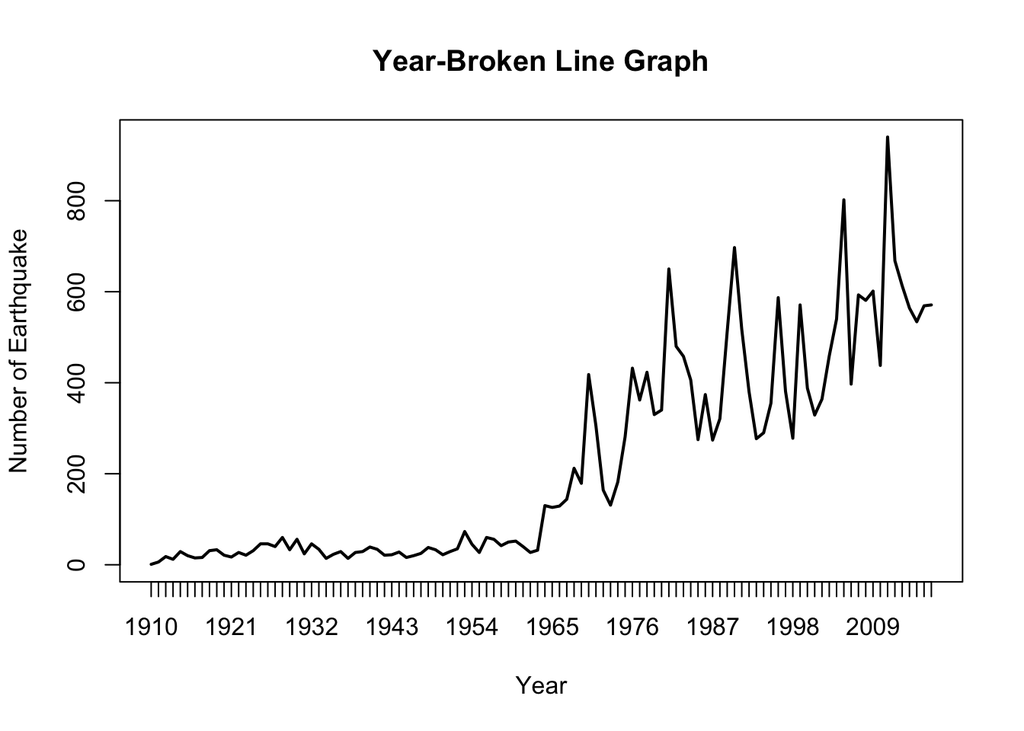

```r
plot(year_table, "l", xlab = "Year", ylab = "Number of Earthquake",
     main = "Year-Broken Line Graph")
```

## Month - bar graph

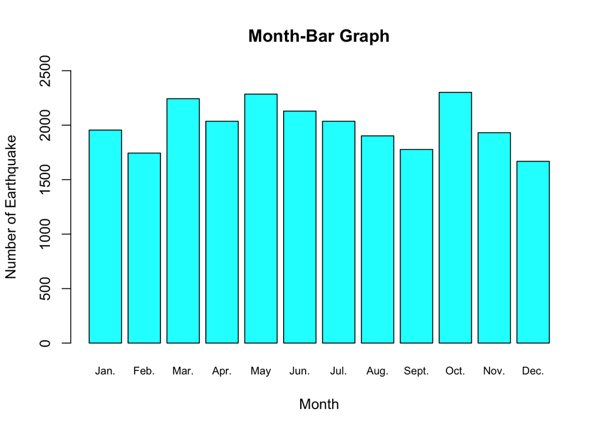

```r
barplot(month_table, xlab = "Month", ylab = "Number of Earthquake",
        ylim = c(0, 2500), col = 5, main = "Month-Bar Graph",
        args.legend = month_levels, cex.names = .75)
```

## Hour - pir chart

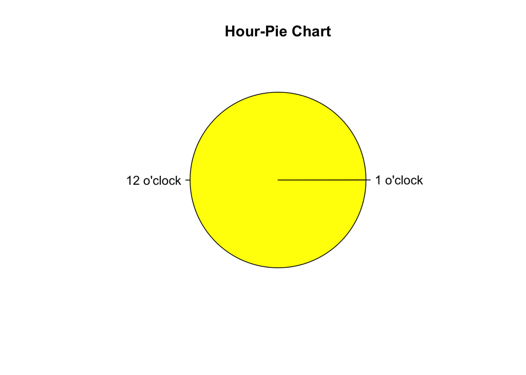

```r
pie_labels <- c("1 o'clock", "12 o'clock")
pie(hour_table, labels = pie_labels, col = "yellow", main = "Hour-Pie Chart")
```

## Latitude and Longitude - boxplots & scatter plots

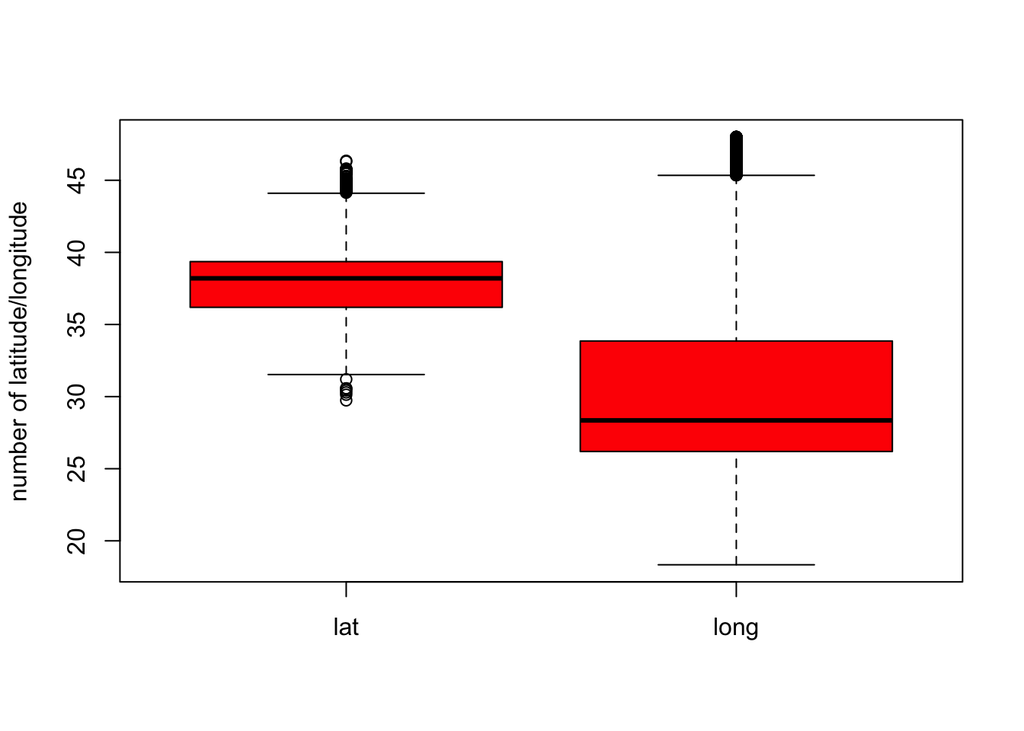

```r
boxplot(using_data[,3:4], ylab = "number of latitude/longitude", col = 10)
```

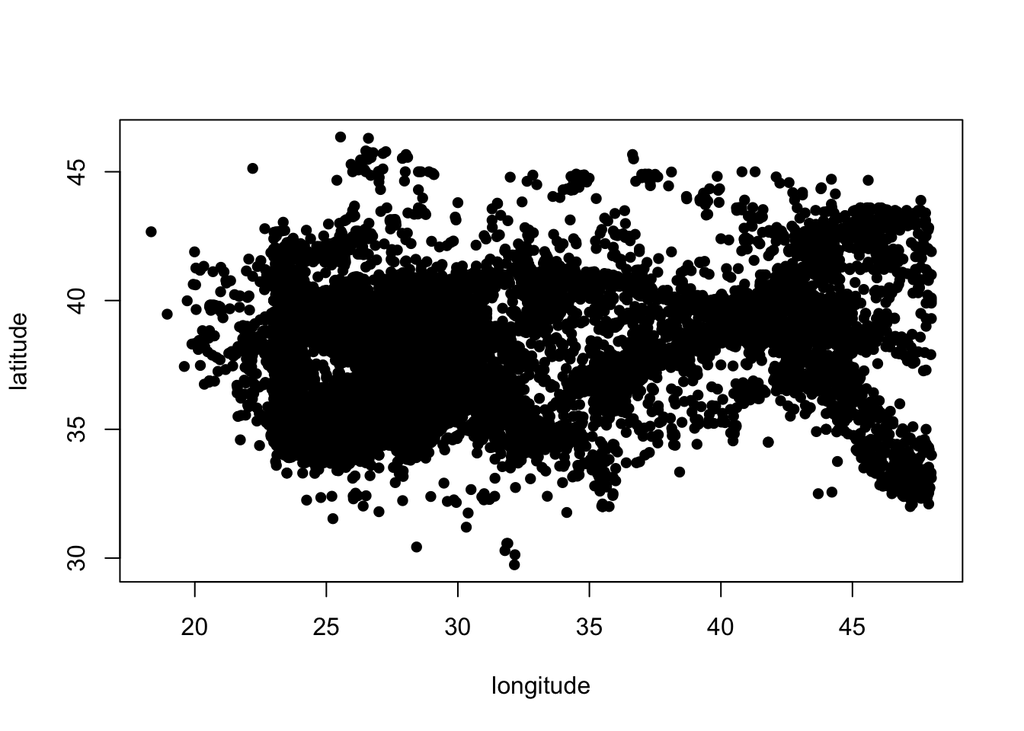

```r
plot(using_data$lat ~ using_data$long, ylab = "latitude", xlab = "longitude", pch=16)
```

## City - bar graph

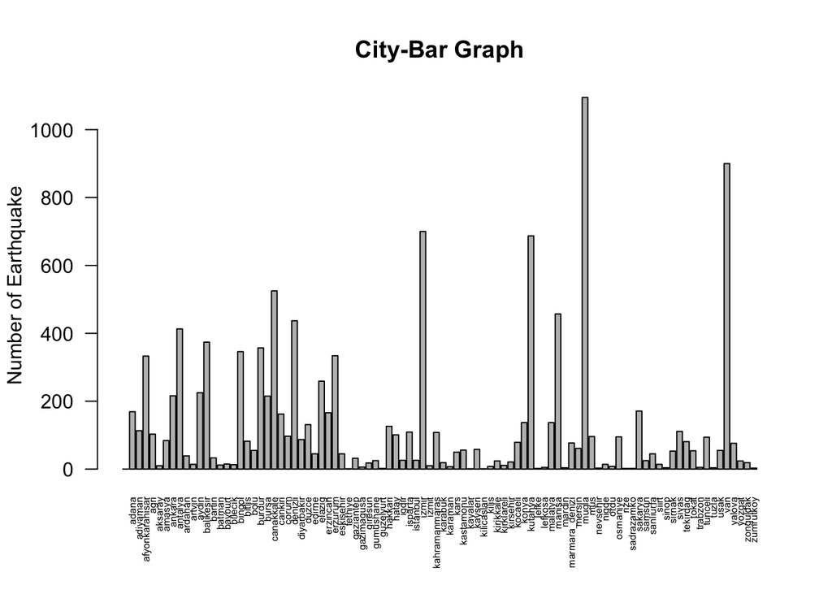

```r
barplot(city, cex.names = 0.5, las =2, ylab = "Number of Earthquake", main = "City-Bar Graph")
```

```r
city_sel <- city %>% as.data.frame %>% filter(city > 500)
city_sel
```

```
##           . Freq
## 1 canakkale  525
## 2     izmir  700
## 3   kutahya  687
## 4     mugla 1095
## 5       van  900
```

## Direction - radar chart

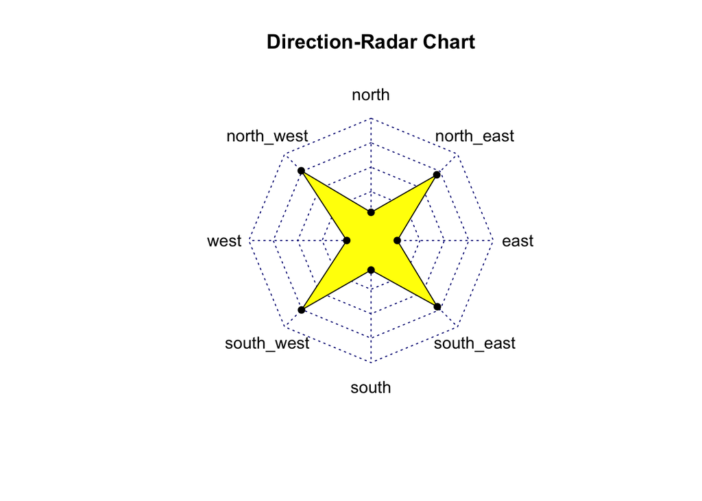

```r
maxmin <- data.frame(north = c(2500, 0), north_west = c(2500, 0), west = c(2500, 0),
                     south_west = c(2500, 0), south = c(2500, 0), south_east = c(2500, 0),
                     east = c(2500, 0),north_east = c(2500, 0))
dir <- data.frame(north = 576, north_west = 2019, west = 497, south_west = 2011, south = 605,
                  south_east = 1917, east = 536,north_east = 1901)
dir2 <- rbind(maxmin,dir)
radarchart(dir2, axistype = 0, seg = 5, centerzero = T, title = "Direction-Radar Chart",
           pfcol = "yellow")
```

## Distance - histograms / broken line graph

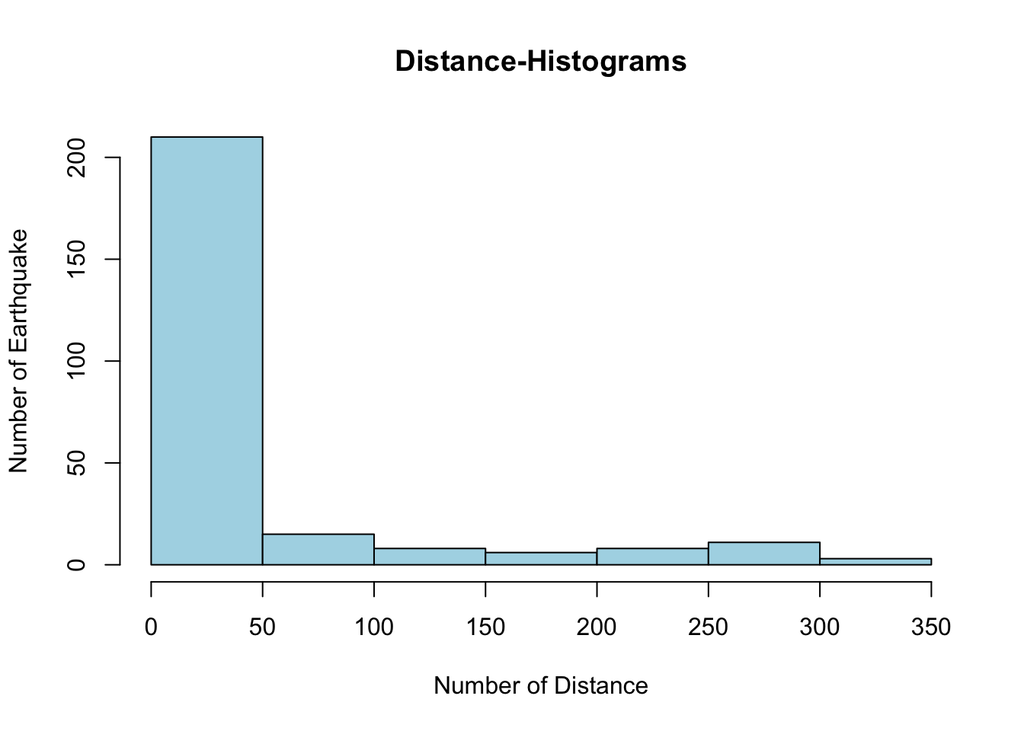

```r
hist(distance, col = "lightblue", main = "Distance-Histograms", ylab = "Number of Earthquake",
     xlab = "Number of Distance")
```

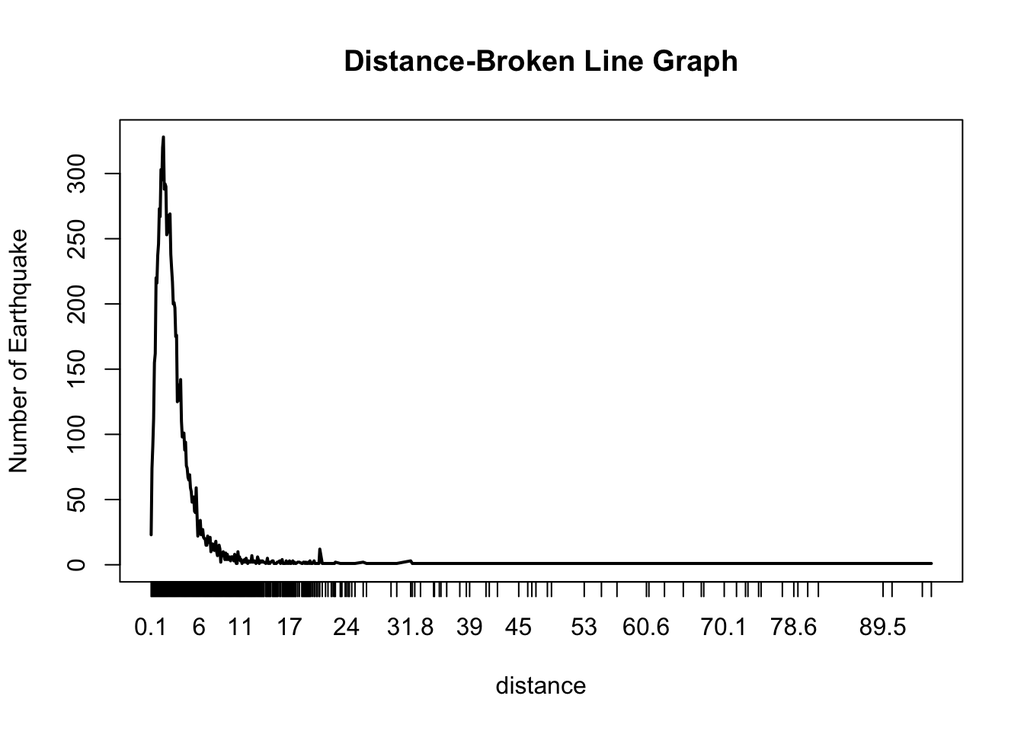

```r
plot(distance, "l", main = "Distance-Broken Line Graph",
     ylab = "Number of Earthquake", xlab = "distance")
```